# UberDataFinalPres

```r
#The violin plot shows the price per mile (Price/Distance) compared to the time of day. As seen in the graph, the most expensive price per mile occurs around 12 pm. At all other hours of the day, the price per mile remains relatively constant. The stark rise in price at noon implies that there is a strong demand for uber rides at that time.
```

[output not shown]

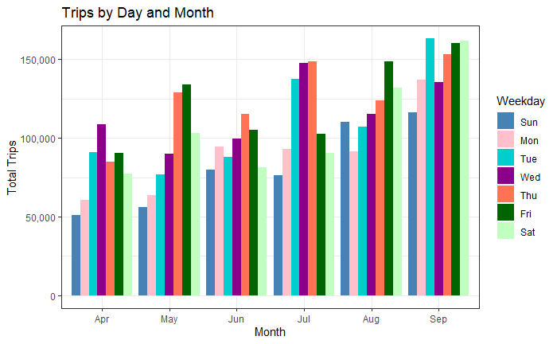

```r
colors=c("steelblue","pink","cyan3","darkmagenta","coral1","darkgreen","darkseagreen1")
month_weekday <- data_2014%>%
         group_by(month, dayofweek) %>%
             dplyr::summarize(Total = n())
ggplot(month_weekday, aes(month, Total, fill = dayofweek)) +
       geom_bar( stat = "identity", position = "dodge") +
          ggtitle("Trips by Day and Month") +
           scale_y_continuous(labels = comma) +
           scale_fill_manual(values = colors)+theme_bw()+labs(fill="Weekday")+xlab("Month")+ylab("Total Trips")
```

```r
#This histogram compares the month and the total number of Uber trips, while also focusing on the days of the week. For each month, the month is broken down by the days of the week, showing which days were the overall busiest in terms of the number of trips . As the months progress throughout the year in 2014, more uber trips are ordered. As this data set only contains the months April through September, the month of September has the largest amount of uber trips. As for the weekdays, Wednesday had the most trips overall ordered for the month of April, Friday for May, and Thursday for June. Wednesday and Thursday were both extremely busy for July. Friday was by far the busiest day of the week for August. Tuesday, Friday, and Saturday were all very busy for the month of September. Overall, it appears that more ubers are ordered on Wednesdays through Fridays, than the other weekdays. As for the months in 2014 , more ubers were ordered in the later months, as September had the largest overall number of trips in this data set.
```

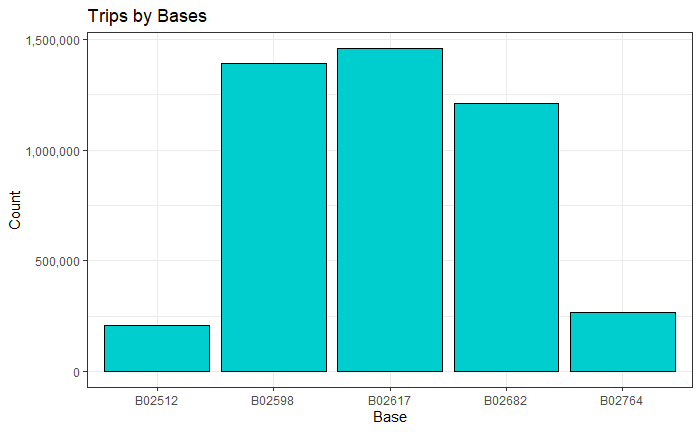

```r
ggplot(data_2014, aes(Base)) +
 geom_bar(fill = "cyan3",color="black") +
 scale_y_continuous(labels = comma) +
 ggtitle("Trips by Bases")+theme_bw()+ylab("Count")
```

```r
#This histogram displays the bases (assigned zones by Uber based on geographic location) and the number of trips ordered from these bases. The bases are located in different parts of New York City and the neighboring suburbs. Base B02512 covers the outskirts of the city into Hoboken. The Base B02598 is located near Rockefeller Center and St. Patrick’s Cathedral. Base B02617 is located near Times Square, which is one of the most populated areas in the city. Therefore, it makes sense that the most number of trips comes from that Base. Base B02682 is located in and around SOHO, which is also a very busy area in the city. Base B02764 is located in the Tribeca area, a less populated area. Thus, we can conclude that more uber trips are ordered from bases B02598, B02617, and B02682 because they are very populated areas of the city.
```

- Introduction

Our goal it to optimize ridesharing, based on several variables Company Time of Day Time of Year (month) Zones created by the company (bases) To achieve this we will start by compare prices within companies (Uber & Lyft) to determine which is better overall From there we will take a deep dive into the best company and provide a comprehensive understanding of the specifics of their ridesharing

- Dataset A

Uber and Lyft trip data from the following source: https://www.kaggle.com/ravi72munde/uber-lyft-cab-prices

‘distance’: The distance between source and destination. ‘cab_type’: Whether the trip was provided by Uber or Lyft. ‘time_stamp’: Epoch time when data was queried (converted). ‘destination’: The destination of the trip. ‘source’: The starting point of the ride. ‘price’: The estimated price for the trip in United States Dollars. ‘surge_multiplier’: The multiplier by which price was increased. ‘id’: The unique identifier number of the trip. ‘product_id’: The identifier number for the provider. ‘name’: Visible type of cab.

- Dataset B We have collected 2014 Uber location and timestamp data from the following source: https://drive.google.com/file/d/1emopjfEkTt59jJoBH9L9bSdmlDC4AR87/view

‘Date/Time’: The date and time when the uber trip took place. ‘Lat’: The latitude of the location where the uber trip took place. ‘Lon’: The longitude of the location where the uber trip took place. ‘Base’: Prescribed regions by Uber.

- How do Uber and Lift Change prices during the day

Does either company have changing prices during the day? Which company shows more price consistency? What are the overall price trends?

- Sharing Rides with other users

Advantages in riding with other people Which company has better shared ride prices? Is this consistent for Lyft across all rides?

- Comparing Uber and Lift prices by Distance

Do Uber and Lyft charge the same prices? Are longer trips priced the same?

- Uber Price vs. Distance by Uber type & Correlation

Which type of Uber is most cost efficient per distance?

- Trips by Hour

Highest price/ mile at noon

Other times of day remain consistent with price

- Daily Rides Per Hour

Trip Activity over Span of 24 Hours Peak times are easily distinguished Activity can be traced to normal movement of peoples travel throughout the day.

- Day by Hour for Total Trips

Heat Map distinguishes Peak activity hours along with a correlation to days in a month. Is there consistency in the times of days people are active and inactive on Uber?

- Trips by Month

Pie Chart shows 6 Months of the year and the total number of rides that are given each month. Does the time of year provide any context to when the number of rides might be higher?

- Trips by Day and Month

Total number of Trips based on Month and Day of the week

Are certain months or weekdays busier For Uber?

- Trips by Bases

Total number of Trips based on the Base (Uber Zones based on location)

Base B02617 located in high Populated area of city (Times Square)

- Conclusion

Lyft is more expensive than Uber overall Lyft Shared rides cheaper than Uber pooled rides But Uber has overall better prices for individual riders Uber rides are more common around dinner time/ early evening near the weekends, which can make them more expensive during “off-peak” times (noon) Uber Pool is the most cost efficient Uber type per distance. More Uber rides are ordered in highly populated areas

- References

Chang, W. (2021, September 23). 13.17 Creating a Map | R Graphics Cookbook, 2nd edition. R Graphics Cookbook, 2nd Edition. https://r-graphics.org/recipe-miscgraph-map Converting unix time into date-time via excel. (2017, September 9). Stack Overflow. https://stackoverflow.com/questions/46130132/converting-unix-time-into-date-time-via-excel R: as.POSIXct timezone and scale_x_datetime issues in my dataset. (2016, March 25). Stack Overflow. https://stackoverflow.com/questions/36227130/r-as-posixct-timezone-and-scale-x-datetime-issues-in-my-dataset Uber & Lyft Cab prices. (2019, June 24). Kaggle. https://www.kaggle.com/ravi72munde/uber-lyft-cab-prices